# Geospatial Data Science - Final Project

Alejandro Zimmerman, Dino Toskic, Raúl Villacorta

2024-03-28

# Introduction

Our final project is inspired in the methodology used in the FTC v. Staples case to measure the effects of market structure on prices (Baker (1999) provides a brief summary of the case). Specifically, we study the effect of entry and exit on diesel prices in the retail market in Madrid.

FTC v. Staples utilized a price-concentration regression to assess how the presence of competitors in the market affects pricing. Similarly, our project employs this methodology to estimate the impacts of entry and exit within the catchment area of a gas station on diesel prices.

The methodological framework we use in this project is also similar to Perdiguero & Borrell (2019), but the research question and the methodology are different:

- While Perdiguero & Borrell (2019) have the objective of identifying an “optimal” catchment based on the effects of market structure on prices for market definition purposes, we take this catchment area as given and focus on the effect of entry and exit on prices.
- Also, Perdiguero & Borrell (2019) use a cross-section for the week of 31 July 2005, and do not control for unobservables at the gas station and time level. We use a panel dataset that allows us to control for unobservables at the gas station and month level.

To control for endogeneity of entry and exit, we use a simple instrument based on the number of competitors outside of the catchment area for each gas station. If the catchment area is correctly defined, this instrument would correctly capture market conditions affecting entry and exit likelihood in Madrid (meeting the relevance condition) without directly influencing prices (satisfying the exogeneity condition).

To run this instrumental variables regression, we define catchment areas using a 7-minute driving distance and count both same-brand gas stations and competitors’ stations inside and outside these areas. For catchment area calculations, we utilize the osrm library, complemented by various analytical tools acquired during the course to compute the endogenous variables and the instruments.

# Dataset

Since 2007, Spanish gas stations have had to submit daily prices to regulatory bodies under ITC/2308/2007, with this data being publicly available in various formats. However, accessing historical data directly or in bulk is not possible, although specific daily records from January 1, 2007, to the present can be obtained via an API.

To make use of this information, we use the dataset “Daily Prices for Spanish Gas Stations (2007-2023)” compiled by the author “mauriciy” and available in the Kaggle webpage (https://www.kaggle.com/datasets/mauriciy/daily-spanish-gas-prices/data) and the companion Python code to process the data (https://www.kaggle.com/code/mauriciy/daily-prices-for-spanish-gas-stations-with-duckdb). This dataset is a compilation of information of gas stations on a daily basis.

According to the description of the dataset available in the Kaggle webpage, compiling a historical dataset requires daily queries, leading to a vast number of entries, many of which are redundant due to infrequent price changes. To take this into account, we use only the first day of each month for our analysis.

# Data processing and spatial tools

We use the following libraries:

```r
rm(list = ls())

library(arrow)
library(sf)
library(dplyr)
library(ggplot2)
library(readxl)
library(tidyr)
library(glue, include.only = "glue_data")
library(scales, exclude = c("discard", "col_factor"))
library(osrm)
library(purrr)
library(haven)
library(Statamarkdown)
```

And the following datasets:

- “df” is the dataset with detailed information of gas stations in Madrid, obtained from Kaggle.
- “map” is a map of Spain. We use only the information corresponding to Madrid (“Comunidad de Madrid”).
- “brands” is a dataset that assigns each gas station name to a specific brand.

```r
df <- read_parquet("C:/Users/Raul/OneDrive - Macroconsult S.A/Desktop/gas_stations_madrid.parquet") %>%
  select(station_id, gasoline_95E5, diesel_A, name, longitude, latitude, year, month) %>%
  st_as_sf(coords = c('longitude', 'latitude'), crs = 4326, remove = FALSE) %>%
  st_transform(crs = 32630)

map <- read_sf("C:/Users/Raul/OneDrive - Macroconsult S.A/Desktop/gadm41_ESP_shp") %>%
  filter(NAME_1 == "Comunidad de Madrid") %>%
  select(NAME_1)

brands <- read_excel("C:/Users/Raul/OneDrive - Macroconsult S.A/Desktop/Brands.xlsx")

df <- left_join(df, brands, by = "name")

rm(brands)
```

We create a dataset with unique gas stations:

```r
summary_df <- df %>%
  mutate(date = as.Date(paste(year, month, "01", sep = "-"))) %>%
  arrange(station_id, date) %>%
  group_by(station_id) %>%
  summarise(first_date = min(date), last_date = max(date)) %>%
  {st_set_geometry(., NULL)}

df <- df %>%
  distinct(station_id, .keep_all = TRUE) %>%
  st_as_sf(coords = c('longitude', 'latitude'), crs = 4326, remove = FALSE) %>%
  st_transform(crs = 32630) %>%
  left_join(summary_df, by = "station_id") %>%
  select(-year, -month)

rm(summary_df)
```

And then calculate isochrones for each gas station using the “osrm” library:

```r
options(osrm.profile = "car")

mtc_iso <- df %>%
  mutate(iso = map2(longitude, latitude, function(lon, lat) {
    osrmIsochrone(loc = c(lon, lat), breaks = 7, res=40)
  })) %>%
  st_drop_geometry() %>%
  unnest(iso) %>%
  st_set_geometry("geometry") %>%
  st_transform(crs = 32630) %>%
  select(-id, -isomin, -isomax)
```

The results are the following:

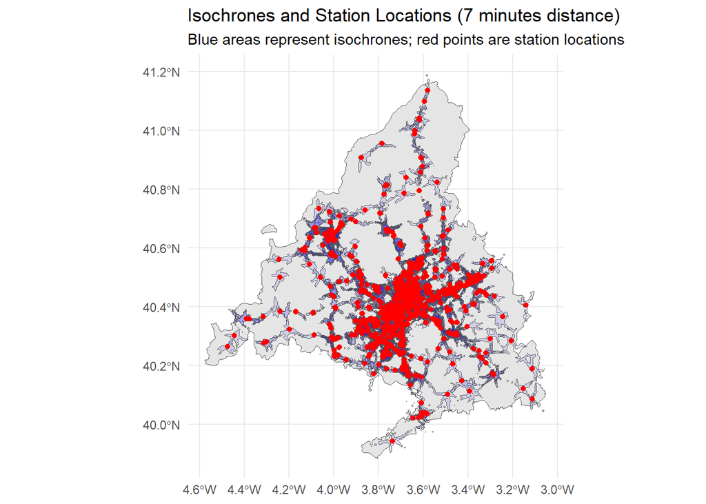

```r
ggplot() +
  geom_sf(data = map) +
  geom_sf(data = mtc_iso, fill = "blue", alpha = 0.1) +
  geom_sf(data = df, color = "red") +
  theme_minimal() +
  labs(title = "Isochrones and Station Locations (7 minutes distance)",
       subtitle = "Blue areas represent isochrones; red points are station locations")
```

Finally, we create our final dataset using the following procedure:

- We use the function “count_brand_observations” to count the number of observation from the same brand and other brands inside and outside the catchment area for each gas station in a given month.
- We use the function “process_observation” to create one observation for each gas station and month, and assign the variables created in the previous step.
- We merge our data with the original dataset from Kaggle to recover the information about prices.

```r
# Function "count_brand_observations":

count_brand_observations <- function(date, points_inside, observation_brand, observation_id, df) {
  active_points_inside = filter(points_inside, date >= first_date & date <= last_date & station_id != observation_id)
  same_brand_count_inside <- sum(active_points_inside$brand == observation_brand, na.rm = TRUE)
  different_brand_count_inside <- sum(active_points_inside$brand != observation_brand, na.rm = TRUE)
  active_points_outside = filter(df, date >= first_date & date <= last_date & station_id != observation_id)
  same_brand_count_outside = sum(active_points_outside$brand == observation_brand & !(active_points_outside$station_id %in% points_inside$station_id), na.rm = TRUE)
  different_brand_count_outside = sum(active_points_outside$brand != observation_brand & !(active_points_outside$station_id %in% points_inside$station_id), na.rm = TRUE)

  return(c(same_brand_count_inside, different_brand_count_inside, same_brand_count_outside, different_brand_count_outside))
}

# Function "process_observation":

process_observation <- function(observation, df) {
  points_inside <- st_filter(df, observation)
  monthly_dates <- seq(from = observation$first_date, to = observation$last_date, by = "month")
  monthly_dates <- tibble(
    date = monthly_dates,
    station_id = rep(observation$station_id, length(monthly_dates))
  )
  counts <- map(monthly_dates$date, ~count_brand_observations(
    .x,
    points_inside,
    observation$brand,
    observation$station_id,
    df
  ))
  counts_unlisted <- do.call(rbind, counts)
  monthly_dates$same_brand_count_inside <- counts_unlisted[,1]
  monthly_dates$different_brand_count_inside <- counts_unlisted[,2]
  monthly_dates$same_brand_count_outside <- counts_unlisted[,3]
  monthly_dates$different_brand_count_outside <- counts_unlisted[,4]
  return(monthly_dates)
}

# Merge with original dataset:

results <- map_dfr(1:nrow(mtc_iso), function(x) process_observation(mtc_iso[x, ], df))

final_df <- read_parquet("C:/Users/Raul/OneDrive - Macroconsult S.A/Desktop/gas_stations_madrid.parquet") %>%
  mutate(date = as.Date(paste(year, month, "1", sep = "-"))) %>%
  select(station_id, diesel_A, date)

final_df <- left_join(results, final_df, by = c("station_id" = "station_id", "date" = "date"))
```

The final dataset is exported to Stata to run the regressions:

```r
write_dta(final_df, "C:/Users/Raul/OneDrive - Macroconsult S.A/Desktop/final_dataset.dta")
```

# Specification and results

## Specification

We run the following regression:

$$ln(P_{it}) = \alpha_0 + \alpha_1 N^o_{it} + \alpha_2 N^r_{it} +
\gamma_{i} + \lambda_{t} + \varepsilon_{it}$$

Where:

- $P_{it}$ is the price of gas station $i$ in month $t$.
- $N^o_{it}$ is the number of gas stations of the same brand within the catchment area of gas station $i$ in month $t$.
- $N^r_{it}$ is the number of gas stations of different brands within the catchment area of gas station $i$ in month $t$.
- $\gamma_{i}$ and $\lambda_{t}$ are fixed effects at the gas station and month level respectively.

As mentioned in previous sections, since $N^o_{it}$ and $N^r_{it}$ could be endogenous, we use the number of gas stations of the same brand outside of the catchment area and the number of gas stations of different brands outside of the catchment area as instruments for both variables.

To account for potential correlation in the variance of the error term, we include clustered standard errors at the gas station level.

## Results

To create the dependent variable $ln(P_{it})$ we transformed the price data into logarithmic form using Stata. The regression was executed with the following Stata command:

```stata
use "C:/Users/Raul/OneDrive - Macroconsult S.A/Desktop/final_dataset.dta", clear
gen lnp = ln( diesel_A )
ivreghdfe lnp ( same_brand_count_inside different_brand_count_inside = same_brand_count_outside different_brand_count_outside), absorb( date station_id ) cluster(station_id)
```

```
(5,455 missing values generated)

(dropped 8 singleton observations)
(MWFE estimator converged in 6 iterations)

IV (2SLS) estimation
--------------------

Estimates efficient for homoskedasticity only
Statistics robust to heteroskedasticity and clustering on station_id

Number of clusters (station_id) =    857              Number of obs =   124728
                                                      F(  2,   856) =     7.96
                                                      Prob > F      =   0.0004
Total (centered) SS     =   37.9140061                Centered R2   =  -0.1528
Total (uncentered) SS   =   37.9140061                Uncentered R2 =  -0.1528
Residual SS             =  43.70842418                Root MSE      =   .01873

------------------------------------------------------------------------------
             |               Robust
         lnp | Coefficient  std. err.      t    P>|t|     [95% conf. interval]
-------------+----------------------------------------------------------------
same_b~nside |   .0268501   .0126252     2.13   0.034     .0020702      .05163
differ~nside |  -.0022756   .0007171    -3.17   0.002     -.003683   -.0008682
------------------------------------------------------------------------------
Underidentification test (Kleibergen-Paap rk LM statistic):             20.264
                                                   Chi-sq(1) P-val =    0.0000
------------------------------------------------------------------------------
Weak identification test (Cragg-Donald Wald F statistic):             1282.076
                         (Kleibergen-Paap rk Wald F statistic):         11.717
Stock-Yogo weak ID test critical values: 10% maximal IV size              7.03
                                         15% maximal IV size              4.58
                                         20% maximal IV size              3.95
                                         25% maximal IV size              3.63
Source: Stock-Yogo (2005).  Reproduced by permission.
NB: Critical values are for Cragg-Donald F statistic and i.i.d. errors.
------------------------------------------------------------------------------
Hansen J statistic (overidentification test of all instruments):         0.000
                                                 (equation exactly identified)
------------------------------------------------------------------------------
Instrumented:         same_brand_count_inside different_brand_count_inside
Excluded instruments: same_brand_count_outside different_brand_count_outside
Partialled-out:       _cons
                      nb: total SS, model F and R2s are after partialling-out;
                          any small-sample adjustments include partialled-out
                          variables in regressor count K
------------------------------------------------------------------------------

Absorbed degrees of freedom:
-----------------------------------------------------+
 Absorbed FE | Categories  - Redundant  = Num. Coefs |
-------------+---------------------------------------|
        date |       199           1         198     |
  station_id |       857         857           0    *|
-----------------------------------------------------+
* = FE nested within cluster; treated as redundant for DoF computation
```

The relatively modest impact of different-brand stations on prices might be explained by factors such as:

- The heterogeneity of competitive effects, where the presence of more directly competing (stronger) rival brands could exert more significant price pressure.
- In February 2015, Spain’s Competition Authority fined five of the largest oil operators in Spain as sanctions for price collusion. Our results may be affected by the effect of the cartel on competition in Madrid.

# Caveats

Our results are subject to the following caveats:

- Due to time constraints, we did not explore how variations in catchment area sizes might affect our results.
- The exogeneity of external gas stations (not within the catchment areas) in influencing prices has not been rigorously tested. Future research could investigate this by expanding the catchment area definition or focusing on more distantly located stations.
- As mentioned in the previous section, the impact of competition may vary with the degree of brand rivalry, suggesting a need for further investigation into the nuances of brand competition beyond the scope of this project.

# References

Baker, J. B. (1999). Econometric analysis in FTC v. Staples. Journal of Public Policy & Marketing, 18(1), 11-21.

Perdiguero, J., & Borrell, J. R. (2019). Driving competition in local markets with near-perfect substitutes: an application on the Spanish retail gasoline market. Empirical Economics, 57(1), 345-364.